# Application html_document

Groupe 5

2024-05-25

## 0.1 Bibliothèques

```r
library(tidyverse)
library(sf)
library(tmap)
#remotes::install_github("MaelTheuliere/variousdata")
library(variousdata)
```

# 1 Introduction

Dans le cadre du cours de Statisitiques agricoles, il nous a été demandé de produire des indicateurs par ménages et par zones du Sénégal dans le but de mieux nous familiariser avec les situations qui prévalent.

# 2 Préparation des données

## 2.1 Importation de la première feuille

```r
library(readxl)
path <- here::here()
way <- paste0(path,"/application beamer et html/base/TAPE_2022.xlsx")
donnees = read_xlsx(way,sheet= 1)
donnees = data.frame (donnees)
```

## 2.2 Renommer la variable _index en key

D’abord, nous allons afficher les noms des variables

```r
library(dplyr)
colnames(donnees)
```

[output not shown]

Nous allons maintenant changer la variable index en key

```r
names(donnees)[names(donnees) == "X_index"] <- "key"
```

## 2.3 Retention des variables utiles

Les variables utiles retenues sont les suivantes :

```r
donnees = select(donnees,country,starts_with("loca"),hh_men:dest,seedsexp,fertexp,key)
```

## 2.4 Etiquettage de la variable country

Dans cette partie, nous allons créer une variable comportant les etiquettes des pays.

```r
country_code = read_xlsx(paste0(path,"/application beamer et html/base/country_codes.xlsx"))

donnees = merge(donnees,country_code, by = "country")
```

Nous allons présenter les pays présents dans la base.

```r
table(donnees$country_2)
```

[output not shown]

Les pays présents dans la base sont l’Argentine, Brésil, Cambodge, Gabon, Guinée équatoriale, Indonésie, Norvège, Ouganda, Pérou, Portugal, Sénégal et Suisse.

## 2.5 Filtrer les ménages sénégalais

Le code du Sénégal est 195.

```r
donnees_filtre = subset(donnees,country == 195)
```

# 3 Nettoyage des données

## 3.1 Application du premier niveau de nettoyage

Dans cette partie, il sera question de nettoyer les données. Uniformisons d’abord les localités.

```r
library(dplyr)
library(stringr)

donnees_filtre <- donnees_filtre %>%
  mutate(location1 = tolower(location1),
         location2 = tolower(location2))


donnees_filtre <- donnees_filtre %>%
  mutate(commune = case_when(
    str_detect(location1, "fatick|foundi") ~ "Keur Samba Gueye",
    str_detect(location1, "nior") ~ "Nioro Alassane Tall",
    str_detect(location1, "gain") | str_detect(location2, "gaint") ~ "Gainthe Pathe",
    str_detect(location1, "mouride") ~ "Ida Mouride",
    str_detect(location1, "maka") ~ "Maka Yop",
    str_detect(location1, "diouroup") ~ "Diouroup",
    str_detect(location1, "missira") ~ "Missirah Wadene",
    str_detect(location1, "ndoga") ~ "Ndoga Babacar",
    str_detect(location1, "ndiob|ndiop") ~ "Ndiob",
    str_detect(location1, "ngohe") ~ "Ngohe",
    str_detect(location1, "ngoye") ~ "Ngoye",
    str_detect(location1, "khar") ~ "Niakhar",
    str_detect(location1, "patar") ~ "Patar Sine",
    str_detect(location1, "sinthiou") ~ "Sinthiou Maleme",
    str_detect(location1, "taguine") ~ "Tattaguine",
    str_detect(location1, "toubacouta") ~ "Toubacouta",
    str_detect(location1, "koussanar|tambacounda") ~ "Koussanar",
    TRUE ~ NA_character_
  ))

donnees_filtre <- donnees_filtre %>%
  mutate(commune = case_when(
    location1 == "e" ~ "Ida Mouride",
    location1 == "mbaye" ~ "Tattaguine",
    location1 == "simong bambara" | location1 == "nio" ~ "Nioro Alassane Tall",
    location1 == "kounguel" ~ "Maka Yop",
    location1 == "ndob" ~ "Ndiob", TRUE ~ commune
  ))
```

Nous allons créér la variable *commune*.

```r
donnees_filtre <- donnees_filtre %>%
  mutate(comcode = case_when(
    commune == "Ngoye" ~ 1,
    commune == "Ngohe" ~ 2,
    commune == "Diouroup" ~ 4,
    commune == "Ndiob" ~ 5,
    commune == "Niakhar" ~ 6,
    commune == "Patar Sine" ~ 7,
    commune == "Tattaguine" ~ 8,
    commune == "Keur Samba Gueye" ~ 9,
    commune == "Nioro Alassane Tall" ~ 10,
    commune == "Toubacouta" ~ 11,
    commune == "Gainthe Pathe" ~ 12,
    commune == "Ida Mouride" ~ 13,
    commune == "Maka Yop" ~ 14,
    commune == "Missirah Wadene" ~ 15,
    commune == "Koussanar" ~ 16,
    commune == "Ndoga Babacar" ~ 17,
    commune == "Sinthiou Maleme" ~ 18,
    TRUE ~ NA_integer_
))
# Création de la variable zone

donnees_filtre <- donnees_filtre %>%
  mutate(zone = case_when(
    between(comcode, 1, 8) ~ 1,
    between(comcode, 9, 11) ~ 2,
    between(comcode, 12, 15) ~ 3,
    between(comcode, 16, 18) ~ 4,
    TRUE ~ NA_integer_
  ))

donnees_filtre$zone <- factor(donnees_filtre$zone, levels = c(1, 2, 3, 4), labels = c("Diourbel-Fatick", "Foundiougne Sud", "Kaffrine", "Tambacounda-Ouest"))
```

## 3.2 Inspection de la variable zone

```r
table(donnees_filtre$zone)

#Suppresssion des ménages qui n'ont pas de zone


donnees_filtre = subset(donnees_filtre,!is.na(zone))
```

[output not shown]

## 3.3 Sauvegarde de la base

```r
library(openxlsx)
path1 <- paste0(path,"/application beamer et html/base")
write.xlsx(donnees_filtre, path1, rowNames = FALSE)
```

## 3.4 Importation de la base_culture

```r
library(readxl)
base_culture = read_xlsx(paste0(path,"/application beamer et html/base/TAPE_2022.xlsx"),sheet="c1")
base_culture = data.frame (base_culture)
```

## 3.5 Renomination de la variable _parent_index

```r
names(base_culture)[names(base_culture) == "X_parent_index"] <- "key"
```

## 3.6 Fusion des deux bases

```r
base = merge(base_culture,donnees_filtre, by = "key")
```

Certaines observations n’ont pas été fusionnées car il n’a pas été trouvé de correspondance dans la base ménage.

## 3.7 Elimination des observations pour lesquelles les superficies et les productions sont nulles

```r
base = subset (base, cprod!= 0 & cland != 0 )
```

## 3.8 Imputation des superficies nulles par les rendements moyens des communes

```r
rendement = select(base,commune,cname_label,cprod,cland)
rendement = subset(rendement,cname_label!= 7777)
rendement <- rendement %>%
  group_by(commune,cname_label) %>%
  summarise(Rendement_moyen  = sum(cprod)/sum(cland))
```

Nous allons remplacer les superficies nulles par la production sur le rendement moyen en tenant compte de la commune et de la culture.

```r
base= left_join(base,rendement, by = c("commune","cname_label"))

base <- base %>%
  mutate(cland=ifelse((cland==0 & cname_label!= 7777),cprod/Rendement_moyen,cland))
```

# 4 Calcul des indicateurs

## 4.1 Productivité par hectare des ménages

```r
base_valprod <- select(base,key,zone,cname_label,cland,cgift,cqsold,cprod,cpg)

base_valprod$valprod <- base_valprod$cprod*base_valprod$cpg

base_prod <- base_valprod %>%
  group_by(key)%>%
  summarize(valprod_mng=sum(valprod),surf_ttle_mng=sum(cland))

base_prod$productivite_ha=base_prod$valprod_mng/base_prod$surf_ttle_mng
```

## 4.2 Rendement du mil par ménages

```r
base_mil = subset(base_valprod,cname_label==79)

base_mil <- base_mil %>%
  group_by(key)%>%
  summarize(cprod_total=sum(cprod),cland_total=sum(cland))

base_mil$rendement_mil = base_mil$cprod_total/base_mil$cland_total

base_mil = select(base_mil,key,rendement_mil)
```

## 4.3 Rendement de l’arachide par ménages

```r
base_arachide = subset(base_valprod,cname_label==242)

base_arachide <- base_arachide %>%
  group_by(key)%>%
  summarize(cprod_total=sum(cprod),cland_total=sum(cland))

base_arachide$rendement_arachide = base_arachide$cprod_total/base_arachide$cland_total


base_arachide = select(base_arachide,key,rendement_arachide)
```

## 4.4 Autoconsommation en mil par ménages

```r
base_autoconso_mil = subset(base_valprod,cname_label==79)

base_autoconso_mil<- base_autoconso_mil %>%
  group_by(key)%>%
  summarize(cprod_total=sum(cprod),cgift_total= sum(cgift),cqsold_total= sum(cqsold))

base_autoconso_mil$Auto_cons_mil = (( base_autoconso_mil$cprod_total -
          base_autoconso_mil$cgift_total - base_autoconso_mil$cqsold_total )/base_autoconso_mil$cprod_total)*100

base_autoconso_mil = select(base_autoconso_mil,key,Auto_cons_mil)
```

## 4.5 Autoconsommation en arachide par ménages

```r
base_autoconso_arachide = subset(base_valprod,cname_label==242)

base_autoconso_arachide<- base_autoconso_arachide %>%
  group_by(key)%>%
  summarize(cprod_total=sum(cprod),cgift_total= sum(cgift),cqsold_total= sum(cqsold))

base_autoconso_arachide$Auto_cons_arachide = (( base_autoconso_arachide$cprod_total -
          base_autoconso_arachide$cgift_total - base_autoconso_arachide$cqsold_total )/base_autoconso_arachide$cprod_total)*100

base_autoconso_arachide = select(base_autoconso_arachide,key,Auto_cons_arachide)
```

## 4.6 Productivité par hectare des zones

```r
base_prod_zone <- base_valprod %>%
  group_by(zone)%>%
  summarize(valprod_zone=sum(valprod),surf_ttle_zone=sum(cland))

base_prod_zone$productivite_ha_zone=base_prod_zone$valprod_zone/base_prod_zone$surf_ttle_zone
```

## 4.7 Rendement du mil par zone

```r
base_mil_zone = subset(base_valprod,cname_label==79)

base_mil_zone <- base_mil_zone %>%
  group_by(zone)%>%
  summarize(cprod_total=sum(cprod),cland_total=sum(cland))

base_mil_zone$rendement_mil = base_mil_zone$cprod_total/base_mil_zone$cland_total

base_mil_zone = select(base_mil_zone,zone,rendement_mil)
```

## 4.8 Rendement de l’arachide par zone

```r
base_arachide_zone = subset(base_valprod,cname_label==242)

base_arachide_zone <- base_arachide_zone %>%
  group_by(zone)%>%
  summarize(cprod_total=sum(cprod),cland_total=sum(cland))

base_arachide_zone$rendement_arachide = base_arachide_zone$cprod_total/base_arachide_zone$cland_total

base_arachide_zone = select(base_arachide_zone,zone,rendement_arachide)
```

## 4.9 Autoconsommation en mil par zone

```r
base_autoconso_mil_zone = subset(base_valprod,cname_label==79)

base_autoconso_mil_zone<- base_autoconso_mil_zone %>%
  group_by(zone)%>%
  summarize(cprod_total=sum(cprod),cgift_total= sum(cgift),cqsold_total= sum(cqsold))

base_autoconso_mil_zone$Auto_cons_mil = (( base_autoconso_mil_zone$cprod_total -
          base_autoconso_mil_zone$cgift_total - base_autoconso_mil_zone$cqsold_total )/base_autoconso_mil_zone$cprod_total)*100

base_autoconso_mil_zone = select(base_autoconso_mil_zone,zone,Auto_cons_mil)
```

## 4.10 Autoconsommation en arachide par zone

```r
base_autoconso_arachide_zone = subset(base_valprod,cname_label==242)

base_autoconso_arachide_zone<- base_autoconso_arachide_zone %>%
  group_by(zone)%>%
  summarize(cprod_total=sum(cprod),cgift_total= sum(cgift),cqsold_total= sum(cqsold))

base_autoconso_arachide_zone$Auto_cons_arachide = (( base_autoconso_arachide_zone$cprod_total -
          base_autoconso_arachide_zone$cgift_total - base_autoconso_arachide_zone$cqsold_total )/base_autoconso_arachide_zone$cprod_total)*100

base_autoconso_arachide_zone = select(base_autoconso_arachide_zone,zone,Auto_cons_arachide)
```

# 5 Analyse des résultats par zone

## 5.1 Analyse de la productivité

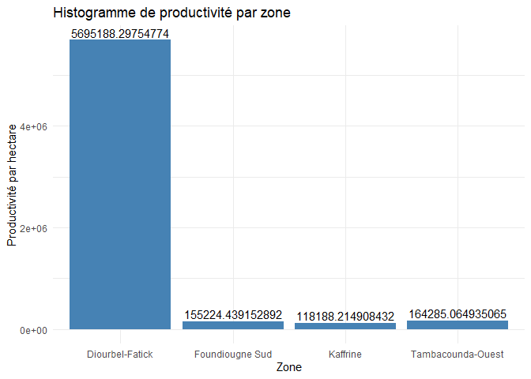

```r
library(ggplot2)
histogramme <- ggplot(base_prod_zone, aes(x = zone, y = productivite_ha_zone)) +
  geom_bar(stat = "identity", fill = "steelblue") +
  geom_text(aes(label = productivite_ha_zone), vjust = -0.3, color = "black", size = 4) +
  labs(title = "Histogramme de productivité par zone",
       x = "Zone",
       y = "Productivité par hectare") +
  theme_minimal()
print(histogramme)
```

L’histogramme ci-dessus traduit une forte productivité dans la zone Diourbel-Fatick et une faible productivité dans les autres zones.

## 5.2 Analyse du rendement en mil

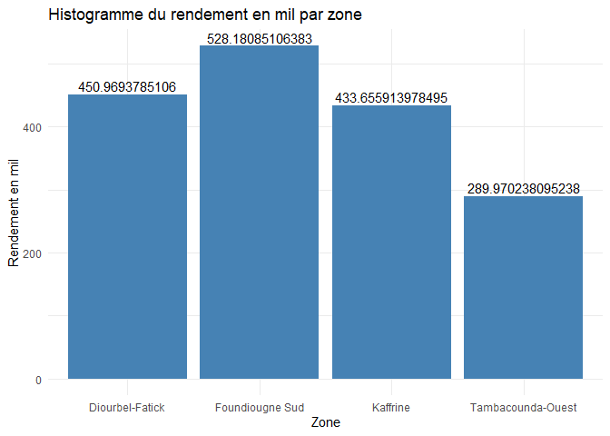

```r
histogramme2 <- ggplot(base_mil_zone, aes(x = zone, y = rendement_mil)) +
  geom_bar(stat = "identity", fill = "steelblue") +
  geom_text(aes(label = rendement_mil), vjust = -0.3, color = "black", size = 4) +
  labs(title = "Histogramme du rendement en mil par zone",
       x = "Zone",
       y = "Rendement en mil") +
  theme_minimal()
print(histogramme2)
```

Les zones de Foundiougne Sud, Diourbel-Fatick et Kaffrine sont propices à la culture du mil car produisant de bons rendements.

## 5.3 Analyse du rendement en arachide

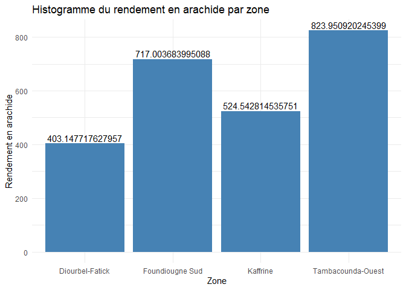

```r
histogramme3 <- ggplot(base_arachide_zone, aes(x = zone, y = rendement_arachide)) +
  geom_bar(stat = "identity", fill = "steelblue") +
  geom_text(aes(label = rendement_arachide), vjust = -0.3, color = "black", size = 4) +
  labs(title = "Histogramme du rendement en arachide par zone",
       x = "Zone",
       y = "Rendement en arachide") +
  theme_minimal()
print(histogramme3)
```

Les zones de Tambacounda-Ouest, Foundiougne Sud et Kaffrine sont relativement propices à la culture de l’arachide.

## 5.4 Autoconsommation en mil par zone

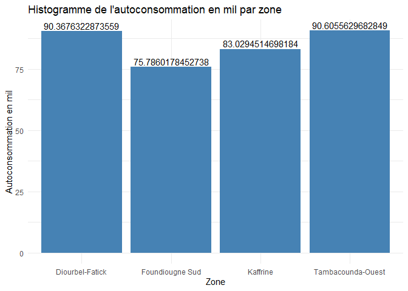

```r
histogramme4 <- ggplot(base_autoconso_mil_zone, aes(x = zone, y = Auto_cons_mil)) +
  geom_bar(stat = "identity", fill = "steelblue") +
  geom_text(aes(label = Auto_cons_mil), vjust = -0.3, color = "black", size = 4) +
  labs(title = "Histogramme de l'autoconsommation en mil par zone",
       x = "Zone",
       y = "Autoconsommation en mil") +
  theme_minimal()
print(histogramme4)
```

Les populations de Diourbel-Fatick, Tambacounda-Ouest et celles de Kaffrine ont une propension à consommer leur production en mil, relativement élévée.

## 5.5 Autoconsommation en arachide par zone

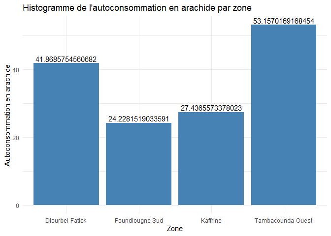

```r
histogramme5 <- ggplot(base_autoconso_arachide_zone, aes(x = zone, y = Auto_cons_arachide)) +
  geom_bar(stat = "identity", fill = "steelblue") +
  geom_text(aes(label = Auto_cons_arachide), vjust = -0.3, color = "black", size = 4) +
  labs(title = "Histogramme de l'autoconsommation en arachide par zone",
       x = "Zone",
       y = "Autoconsommation en arachide") +
  theme_minimal()
print(histogramme5)
```

Les populations de Diourbel-Fatick et Tambacounda-Ouest ont une propension à consommer leur production en arachide, relativement élevée.

## 5.6 Un peu de statistique spatiales

### 5.6.1 carte statique avec tmap

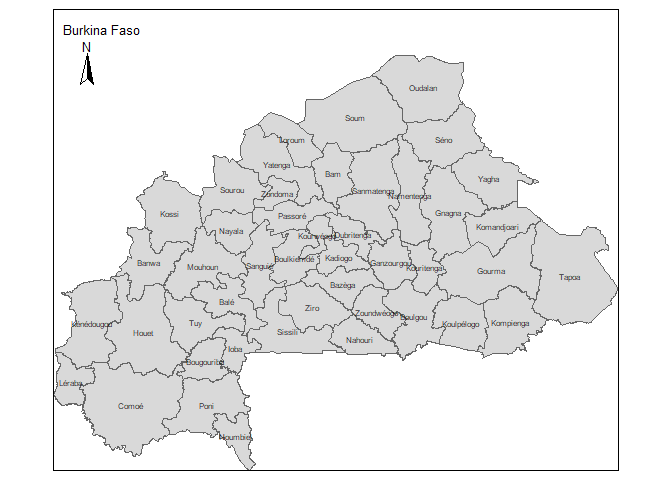

```r
bkf<- read_sf(paste0(path,"/application beamer et html//BKF/gadm41_BFA_2.shp"))
tmap_mode("plot")
bkf_1 <- tm_shape(bkf) +
    tm_polygons() +
   tm_text("NAME_2", size = 0.5, col = "black", alpha = 0.8)+
  tm_layout("Burkina Faso", inner.margins=c(0,0,.1,0), title.size=.8)+
  tm_compass(type = "arrow", position = c("left", "top"))
bkf_1
```

### 5.6.2 Ajout des etiquettes avec tmap

```r
library(openxlsx)
way<- paste0(path,"/application beamer et html/BKF/température.xlsx")
temperature <- read.xlsx(way)
temperature <- data.frame(temperature)
bkf_2<- merge(bkf, temperature, by = "NAME_2", all.x = TRUE)
bkf_2
```

[output not shown]

### 5.6.3 Carte choroplèthe

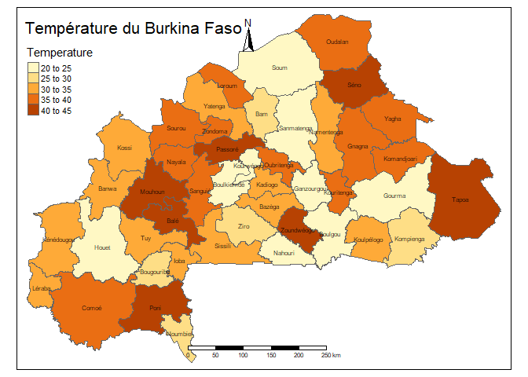

```r
library(tmap)

bkf_2_T <- tm_shape(bkf_2) +
  tm_polygons("Temperature", title = "Temperature") +
  tm_borders("white", lwd = 0.5) +
  tm_text("NAME_2", size = 0.5, col = "black", alpha = 0.8)+
  tm_layout(title = "Température du Burkina Faso")+
  tm_compass(type = "arrow", position = c("left", "top"))+
   tm_scale_bar(position = c("center","bottom"))
bkf_2_T
```

## Avec les Bubbles

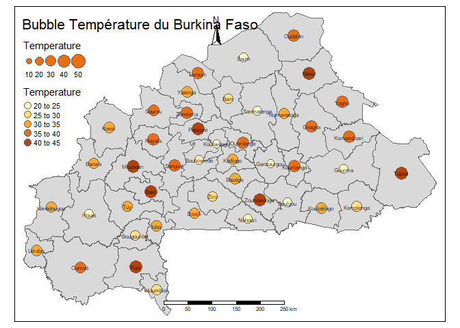

```r
bkf_2_B <- tm_shape(bkf_2) +
  tm_polygons() +
  tm_bubbles(size="Temperature",col="Temperature",textNA = "Valeur manquante")+
  tm_layout(title = "Bubble Température du Burkina Faso")+
  tm_compass(type = "arrow", position = c("left", "top"))+
  tm_compass(type = "arrow", position = c("left", "top"))+
  tm_text("NAME_2", size = 0.5, col = "black", alpha = 0.8)+
   tm_scale_bar(position = c("center","bottom"))
bkf_2_B
```

### farcet

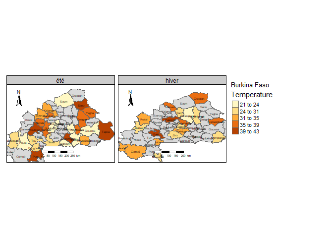

```r
bkf_2_P <- tm_shape(bkf_2) +
  tm_polygons("Temperature", textNA = "Valeur manquante", style = "jenks") +
  tm_facets("Periode")+
  tm_compass(type = "arrow", position = c("left", "top"))+
  tm_text("NAME_2", size = 0.5, col = "black", alpha = 0.8)+
  tm_scale_bar(position = c("center","bottom"))

bkf_1+bkf_2_P
```

### arrange deux carte

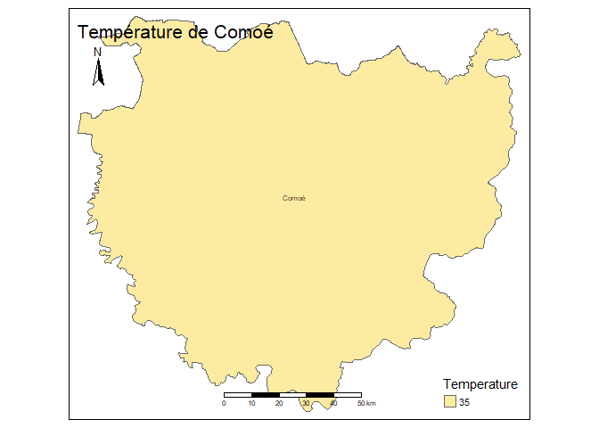

```r
bkf_2_T <- tm_shape(bkf_2) +
  tm_polygons("Temperature", title = "Temperature") +
  tm_borders("white", lwd = 0.5) +
  tm_text("NAME_2", size = 0.5, col = "black", alpha = 0.8)+
  tm_layout(title = "Température du Burkina Faso")+
  tm_compass(type = "arrow", position = c("left", "top"))+
   tm_scale_bar(position = c("center","bottom"))

bkf_2_comoe <- bkf_2 %>%
  filter(bkf_2$NAME_2=="Comoé") %>%
  tm_shape("")+
  tm_polygons("Temperature", title = "Temperature") +
  tm_borders("white", lwd = 0.5) +
  tm_text("NAME_2", size = 0.5, col = "black", alpha = 0.8)+
  tm_layout(title = "Température de Comoé")+
  tm_compass(type = "arrow", position = c("left", "top"))+
  tm_scale_bar(position = c("center","bottom"))
bkf_2_comoe
```

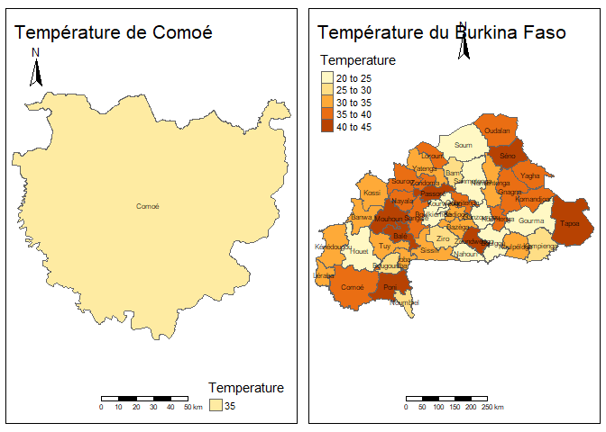

```r
tmap_arrange(bkf_2_comoe,bkf_2_T,nrow=1)
```

### 5.6.4 Carte interactive

```r
tmap_mode("view")

bkf_2_T <- tm_shape(bkf_2) +
  tm_polygons("Temperature", title = "Temperature") +
  tm_borders("white", lwd = 0.5) +
  tm_text("NAME_2", size = 0.5, col = "black", alpha = 0.8)+
  tm_layout(title = "Température du Burkina Faso")+
  tm_compass(type = "arrow", position = c("left", "top"))+
   tm_scale_bar(position = c("center","bottom"))


bkf_2_T
```

[output not shown]